# Chapter 0 - Introduction

به‌نام زیباترین

دانشگاه صنعتی شریف - دانشکده‌ی مهندسی کامپیوتر

جبرخطی

فصل اول: مفاهیم اولیه

علی شریفی

## فهرست مطالب

- بردار
- طول
- زاویه
- ضرب داخلی
- ماتریس
- ماتریس به عنوان تابع!
- ماتریس به عنوان داده!
- ماتریس‌ورزی!
- منابع

## بردار

یک نقطه در فضای اقلیدسی $n$-بعدی، یک $n$تایی به فرم $X=(x_1, x_2, \dots, x_n)$ است که در آن تمام $x_i$ها حقیقی‌اند. جمع و تفریق میان این نقاط، مانند جمع و تفریق مأنوس‌ای است که قبل‌تر هم در فضاهای دو-بعدی و سه-بعدی نیز دیده بودیم. $$ X = (x_1, x_2, \dots, x_n)\\ Y = (y_1, y_2, \dots, y_n)\\ X + Y = (x_1 + y_1, x_2 + y_2, \dots, x_n + y_n) \\ \text{if } a \in \mathbb{R} \text{, then } aX = (ax_1, ax_2, \dots, ax_n) $$ تعابیر هندسی این عملیات‌ها هم مانند حالت دو و سه بعدی است. حاصل جمع دو نقطه، نقطه‌ای است که با نقاط $0$ ، $X$ و $Y$ تشکیل یک متوازی‌الاضلاع می‌دهد. ضرب یک اسکالر در بردار هم به همین نحو؛ برداری است که به نسبت اسکالر منقبض یا منبسط شده‌است.

بازگشت به فهرست مطالب

## طول

تا کنون شما با مفهوم طول در فضاهای اقلیدسی دو و سه بعدی در دوران راهنمایی و دبیرستان آشنا شده‌اید. این روابط با مدد از قضیه فیثاغرث به دست می‌آیند:

$$ \text{if } X \in \mathbb{R}^2 \text{, then } \lVert X \rVert_2 = \sqrt{x_1 ^ 2 + x_2^2}\\ \text{if } X \in \mathbb{R}^3 \text{, then } \lVert X \rVert_2 = \sqrt{x_1 ^ 2 + x_2^2 + x_3^2} $$

حال ما می‌خواهیم تعریفی از طول ارائه کنیم و این مفهوم را به معنای عام در فضاهای اقلیدسی پیاده کنیم. یک تابع طول، یک تابع $\lVert . \rVert$ است که به هر بردار، طولش را نسبت می‌دهد. خواص یک نرم سازگار به شرح زیر است:

$$ \lVert . \rVert : \mathbb{R}^n \to \mathbb{R}^{\geq 0} \\ \lVert X \rVert = 0 \iff X = 0 \\ \forall t \in \mathbb{R}, X \in \mathbb{R}^n: \lVert tX \rVert = |t|\lVert X \rVert \\ \forall X, Y \in \mathbb{R}^n: \lVert X + Y \rVert \leq \lVert X \rVert + \lVert Y \rVert $$

تفسیر این روابط کار سختی نیست، در واقع رابطه اول اذعان می‌کند که تنها بردار از طول ۰، نقطه مبدأ است و رابطه دوم بیان می‌کند که اندازه اسکیل شده یک بردار چه رابطه‌ای با خود بردار دارد و رابطه سوم را که از مدت‌ها پیش می‌شناسید، تحت عنوان نابرابری مثلث، یا اصل «حمار»، که بیان می‌کند در هر مثلث، مجموع هر دو ضلع، از ضلع سوم ناکمتر است! انواع مختلفی از نرم‌ها را می‌توان معرفی کرد. یک خانواده معروف از نرم‌ها، نرم‌های $l_p$ اند:

$$ p \geq 1, \lVert . \rVert_p : \mathbb{R}^n \to \mathbb{R}^{\geq 0} \\ \lVert X \rVert_p = (|x_1| ^ p + \dots + |x_n|^p)^{\frac{1}{p}} $$

به ازای سه مقدار $p$ این نرم‌ها معروف‌اند و نام‌های خاصی گرفته‌اند. به ازای $p=1$ ، نرم به شکل زیر در می‌آيد:

$$ \lVert X \rVert_1 = |x_1| + \dots + |x_n| $$

که این فاصله، به فاصله «منهتن» معروف است. (در صورت علاقه می‌توانید جستجو کنید که وجه تسمیه چیست!) به ازای $p=2$ نیز فاصله اقلیدسی مأنوس را داریم

$$ \lVert X \rVert_2 = (|x_1| ^ 2 + \dots + |x_1|^2)^{\frac{1}{2}} = \sqrt{|x_1| ^ 2 + \dots + |x_n|^2} $$

همچنین حالت حدی این نرم، یعنی وقتی $p \to \infty$ که به نرم ماکزیمم معروف است.

$$ \lVert X \rVert_\infty = \max_{i=1, 2, \dots, n} |x_i| $$

بازگشت به فهرست مطالب

## زاویه

حال به معرفی مفهوم زاویه می‌پردازیم. همانطور که احتمالا می‌دانید، تصور فضاهای با بعد بیش از ۳ برای ما کار راحتی نیست. (اگر نخواهیم بگوییم نشدنی است!) پس برای تعریف زاویه، باید از تعاریف جبری استفاده کنیم. ما با ضرب داخلی دو بردار در دو و سه بعد آشنا هستیم. اگر ضرب داخلی دو بردار را با $\langle X, Y \rangle$ نمایش دهیم، در این حالت می‌دانیم.

$$ \langle X, Y \rangle = \lVert X \rVert_2 \lVert Y \rVert_2 \cos(\angle XY) = X_1Y_1 + X_2Y_2 $$

مشابه تساوی بالا برای بعد ۳ نیز برقرار است. توجه کنید که تساوی دوم، نتیجه نوشتن قضیه کسینوس‌ها در مثلث $\triangle OXY$ است. حال با این تعریف، می‌توان زاویه میان دو بردار را تعریف کرد؛

$$ \angle XY = \cos^{-1}\bigg(\frac{X_1Y_1 + X_2Y_2}{\lVert X \rVert_2 \lVert Y \rVert_2}\bigg) $$

توجه کنید که رابطه فوق، بسیار رابطه مفیدی است و کاربردهای زیادی در زمینه‌های یادگیری، مانند NLP پیدا کرده است. به صورت شهودی می‌توان گفت یک راه در نظر گرفتن شباهت دو بردار، زاویه میان آن‌ها است. هرچه این زاویه کوچکتر باشد، دو بردار به یکدیگر نزدیک‌ترند. پس مساله ما برای تعریف زاویه، به تعریف ضرب داخلی دو بردار مبدل شد.

بازگشت به فهرست مطالب

## ضرب داخلی

یک ضرب داخلی، تابعی است که در شرایط زیر صدق می‌کند:

$$ \langle .,. \rangle: \mathbb{R}^n \times \mathbb{R}^n \to \mathbb{R} \\ \forall X, Y, Z \in \mathbb{R}^n, a, b \in \mathbb{R}\\ \langle X,Y \rangle = \langle Y, X \rangle \\ \langle X,aY + bZ \rangle = a\langle X,Y \rangle + b\langle X,Z \rangle \\ \langle X,X \rangle \geq 0 \text{ and } \langle X,X \rangle = 0 \iff X = 0 $$

شرط اول بیان می‌کند که ضرب داخلی، متقارن است. شرط دوم بیان می‌کند که ضرب داخلی، با ثابت نگه‌داشتن یک مولفه، نسبت به مولفه دیگر خطی است، و رابطه سوم می‌گوید که ضرب داخلی، مثبت معین است.

مانند نرم، انتخاب‌های متعددی برای ضرب داخلی وجود دارند، ولی معروف ترین آن‌ها، ضرب اقلیدسی است.

$$ \langle X, Y \rangle = X_1Y_1 + \dots + X_nY_n $$

این ضرب داخلی، رابطه تنگاتنگی با نرم هم‌نام خود دارد:

$$ \lVert X \rVert_2 = \sqrt{\langle X, X \rangle} $$

با این اوصاف، می‌توان در حالت کلی نیز زاویه میان دو بردار را تعریف کرد

$$ \angle XY = \cos^{-1}\bigg(\frac{\langle X, Y \rangle}{\sqrt{\langle X, X \rangle \langle Y, Y \rangle} }\bigg) $$

یک نکته‌ی مهم درباره رابطه بالا این است که دامنه تابع $\cos^{-1}$ مقادیر بازه $[-1,1]$ است، ولی از کجا می‌دانیم که مقدار فوق، در این بازه است؟

**نابرابری کوشی-شوارتز**

$$ \forall X, Y \in \mathbb{R}^n: |\langle X, Y \rangle| \leq \sqrt{\langle X, X \rangle \langle Y, Y \rangle} $$

**برهان.** تعریف می‌کنیم

$$ f(t) = \langle X-tY, X-tY \rangle = \langle X, X \rangle - 2t \langle X, Y \rangle + t^2 \langle Y, Y \rangle $$

توجه کنید $f$ یک سهمی است که همیشه نامنفی است، پس دلتای آن نامثبت است.

$$ \Delta = 4 \langle X, Y \rangle^2 - 4 \langle X, X \rangle \langle Y, Y \rangle \leq 0 \\ $$

بازگشت به فهرست مطالب

## ماتریس

احتمالاً با مفهوم ماتریس در دوران دبیرستان آشنا شده‌اید. (اگر که مثل مفاهیم پرکاربرد مشتق و انتگرال از کتب آموزشی حذف نشده باشد!) تعریف، بسیار ساده است؛ یک ماتریس، آرایه‌ای مستطیلی از اعداد است. حتماً با مفاهیمی مانند ضرب ماتریسی آشنا هستید. آیا تا به حال از خود پرسیده‌اید که چرا باید همچنین چیزهای عجیبی تعریف شده‌باشند؟ یا اصلاً مفهوم این طور ضرب کردن چیست؟

یک ماتریس با $m$ سطر و $n$ ستون که آن را اغلب یک ماتریس $m \times n$ می‌نامیم، و به شکل زیر نمایش می‌دهیم:

$$ A \in \mathbb{R}^{m\times n} \\ A = (a_{ij})_{1\leq i \leq m\\ 1\leq j \leq n} $$

به $a_{ij}$ درایه سطر $i$-ام و ستون $j$-ام ماتریس $A$ گفته می‌شود.

$$ A = \begin{bmatrix} a_{11} & a_{12} & \dots & a_{1n}\\ a_{21} & a_{22} & \dots & a_{2n}\\ \vdots & \vdots & \vdots & \vdots \\ a_{m1} & a_{m2} & \dots & a_{mn} \end{bmatrix} $$

اگر $X$ یک بردار ستونی باشد، ضرب $AX$ را به شکل زیر تعریف می‌کنیم.

$$ AX = \begin{bmatrix} \sum_{j = 1}^{n} a_1jx_j \\ \sum_{j = 1}^{n} a_2jx_j \\ \vdots \\ \sum_{j = 1}^{n} a_mjx_j \end{bmatrix} $$

اگر نیک به تعریف فوق بنگرید، می‌بینید که مولفه $i$-ام تابع حاصل، ضرب سطر $i$-ام ماتریس $A$ و بردار $X$ است.

بازگشت به فهرست مطالب

## ماتریس به عنوان تابع!

فرض کنید $A \in \mathbb{R}^{m\times n}$ یک ماتریس باشد. حال می‌توان تابع $f_A$ را به شکل زیر تعریف کرد:

$$ f_A: \mathbb{R}^n \to \mathbb{R}^m \\ f_A(X) = AX $$

حال می‌توان این سوال را پرسید که اگر $B \in \mathbb{R}^{p\times m}$ باشد و $f_B: \mathbb{R}^m \to \mathbb{R}^p$ به شکل مشابه تعریف شده باشد، $f_B \circ f_A : \mathbb{R}^n \to \mathbb{R}^p$ چه ضابطه‌ای دارد؟

$$f_B \circ f_A = f_{BA}$$

که در آن $BA$ همان ضرب عجیب و غریب دو ماتریس است که در دبیرستان دیده‌اید. با این دید می‌توان آن فرمول‌ها را توجیه کرد!

در واقع در ادامه درس خواهید دید که ماتریس‌ها رابطه تنگاتنگی با رده خاصی از توابع به نام «توابع خطی» دارند. انواع ملموسی از توابع خطی عبارتند از توابع دوران، تصویر کردن، و تقارن!

به عنوان مثال، ماتریس مرتبط با تابعی که هر نقطه‌ای در صفحه را به اندازه $\alpha$ درجه دوران می‌دهد، ماتریس زیر است.

$$ A_{\alpha} = \begin{bmatrix} \cos(\alpha) & -\sin(\alpha) \\ \sin(\alpha) & \cos(\alpha) \end{bmatrix} $$

بازگشت به فهرست مطالب

## ماتریس به عنوان داده!

در کاربردهای امروزه حوزه یادگیری، اغلب از ماتریس‌ها به نحو دیگری استفاده می‌شود. فرض کنید که شما در حال تحقیق روی بیماران یک نوع خاصی از سرطان هستید و می‌خواهید بدانید که چه افرادی در معرض این نوع سرطان‌اند و یا این که از مدتی قبل بتوانید ریسک ابتلا به سرطان را پیش‌بینی کنید. برای این منظور، شما $m$ نفر را جمع می‌کنید که جامعه آماری شما را تشکیل می‌دهند. (با در نظر گرفتن ملاحظات لازم برای این جامعه آماری!) حال برای هر یک از این $m$ نفر، $n$ کمیت مورد نظرتان را که فکر می‌کنید ارتباط مستقیمی با این بیماری دارند، مانند سن، جنسیت، وزن، قد، چربی خون و ... را اندازه می‌گیرید. این داده‌ها را در یک ماتریس $m \times n$ قرار می‌دهید که درایه سطر $i$-ام و ستون $j$-ام، کمیت $j$-ام متناظر با شخص $i$-ام باشد. به این ماتریس در اصطلاح design matrix گفته می‌شود. در واقع شما با استفاده از یک تعریف جبری، راهی برای نمایش داده‌هایتان پیدا کرده‌اید که از قضا بسیار مفید است. (در ادامه درس خواهید دید که چگونه به عنوان مثال می‌توان ابعاد داده را کم کرد و به شکل موثری آن را نمایش داد.)

یک مثال ملموس‌تر از این استفاده، تصاویری هستند که در زندگی روزمره بسیار با آن‌ها کاربرد دارید. یک عکس سیاه-سفید را می‌توان یک ماتریس در نظر گرفت که هر درایه آن، ۰ است اگر پیکسل متناظر سفید باشد و ۱ است اگر که سیاه باشد. به عنوان مثال، ماتریس زیر

$$ \begin{bmatrix} 0 & 0 & 0 & 0 & 0 & 0 & 0 \\ 0 & 1 & 0 & 0 & 0 & 1 & 0 \\ 0 & 0 & 0 & 1 & 0 & 0 & 0 \\ 0 & 0 & 0 & 0 & 0 & 0 & 0 \\ 0 & 1 & 0 & 0 & 0 & 1 & 0 \\ 0 & 0 & 1 & 1 & 1 & 0 & 0 \\ 0 & 0 & 0 & 0 & 0 & 0 & 0 \end{bmatrix} $$

نشان دهنده تصویر زیر است

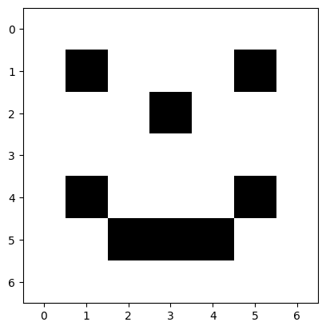

```python
import numpy as np
import matplotlib.pyplot as plt
img = np.zeros((7, 7))
img[[1, 1, 2, 4, 4, 5, 5, 5], [1, 5, 3, 1, 5, 2, 3, 4]] = 1
plt.imshow(img, cmap='binary', interpolation='nearest');
```

در واقع تصاویر رنگی نیز همین هستند. هر رنگ را می‌توان ترکیبی از رنگ‌های قرمز، سبز، و آبی در نظر گرفت. در این صورت برای نمایش دادن هر پیکسل رنگی، به سه مقدار نیاز داریم. پس می‌توان یک تصویر رنگی را سه تا ماتریس در نظر گرفت، که هر یک نشان‌دهنده intensity هر یک از سه رنگ فوق است. اغلب هر یک از مقادیر بین ۰ و ۲۵۵ اند.

بازگشت به فهرست مطالب

## ماتریس ورزی

در این قسمت سعی داریم که نگاهی تازه به ضرب ماتریسی بیندازیم. احتمالا نوع متداول آن را در دبیرستان دیده‌اید. ایده اصلی تمامی این ضرب‌ها، «ضرب بلوکی» ماتریس‌ها است.

**ضرب بلوکی**

فرض کنید $A \in \mathbb{R}^{m \times n}$ و $B \in \mathbb{R}^{n \times p}$ . همچینین فرض کنید $m = m_1 + \dots + m_r$ $n = n_1 + \dots + n_s$ $p = p_1 + \dots + p_t$ در این صورت ماتریس‌های $A$ و $B$ را می‌توان به شکل زیر بلوک بندی کرد. $$ A = \begin{bmatrix} A_{11} & A_{12} & \dots & A_{1s}\\ A_{21} & A_{22} & \dots & A_{2s}\\ \vdots & \vdots & \vdots & \vdots \\ A_{r1} & A_{r2} & \dots & A_{rs} \end{bmatrix} $$ $$ B = \begin{bmatrix} B_{11} & B_{12} & \dots & B_{1t}\\ B_{21} & B_{22} & \dots & B_{2t}\\ \vdots & \vdots & \vdots & \vdots \\ B_{s1} & B_{s2} & \dots & B_{st} \end{bmatrix} $$ که در آن $A_{ij} \in \mathbb{R}^{m_i \times n_j}$ و $B_{jk} \in \mathbb{R}^{n_j \times p_k}$ . در این صورت $$AB = \begin{bmatrix} C_{11} & C_{12} & \dots & C_{1t}\\ C_{21} & C_{22} & \dots & C_{2t}\\ \vdots & \vdots & \vdots & \vdots \\ C_{r1} & C_{r2} & \dots & C_{rt} \end{bmatrix} $$ که در آن $$C_{ik} = \sum_{j = 1} ^ s A_{ij}B_{jk}$$

**حالت اول**

ماتریس را به بلوک‌های $1 \times 1$ تقسیم کنید. در این صورت به همان ضربی که در دوران دبیرستان دیده‌اید می‌رسید.

$$c_{ik} = \sum_{j = 1} ^ n a_{ij}b_{jk} = \langle A_{i,.} B_{., j} \rangle$$

**حالت دوم**

ماتریس $A$ را به بلوک‌های سطری تقسیم کنید و $B$ را به تنهایی یک بلوک بگیرید. در این صورت

$$AB = \begin{bmatrix} A_{1,.}B \\ A_{2,.}B \\ \vdots \\ A_{m,.}B \end{bmatrix} $$

**حالت سوم**

ماتریس $B$ را به بلوک‌های ستونی تقسیم کنید و $A$ را به صورت کامل، یک بلوک بگیرید. در این صورت

$$AB = \begin{bmatrix} AB_{.,1} & \dots & AB_{., p} \end{bmatrix} $$

**حالت چهارم**

ماتریس $A$ را به بلوک‌های ستونی و $B$ را به بلوک‌های سطری تقسیم کنید.

$$ AB = A_{., 1} B_{1, .} + A_{., n} B_{n, .} $$

بازگشت به فهرست مطالب

بازگشت به فهرست مطالب